# Longitudinal Data Analysis

Author

Ba Khuong Cao

# 1. The objectives of the anlysis

The objectives are to:

- Develop an appropriate model to describe the growth curve of children’s weight over time, using the “time structure first” approach.
- Use the model to answer the following research question: How does gender influence the growth trajectory of children’s weight?

# 2. Preliminary setup

```r
# Check whether pacman is available and install if needed
options(repos = c(CRAN = "https://cloud.r-project.org"))
if (!requireNamespace("pacman", quietly = TRUE)) install.packages("pacman")

# Use pacman to install (if needed) and load the required packages
pacman::p_load(haven, dplyr, ggplot2, emmeans, lmerTest)
```

# 3. Load the dataset

```r
# Load the data
asian_data <- read.csv("asian_data.csv")

# Convert all character variables into factors
asian_data <- asian_data |>
  mutate(across(where(is.character), as.factor))

# Use effects coding for categorical variables
options(contrasts = c("contr.sum", "contr.poly"))
# Inspect the structure of the dataset
str(asian_data)
```

```
'data.frame':   1572 obs. of  4 variables:
 $ ChildID: int  2 2 3 3 3 3 22 22 22 22 ...
 $ Age    : num  12.39 27.1 1.77 7.95 12.39 ...
 $ Weight : int  10262 14500 4053 8136 9752 13180 4510 8360 8480 13150 ...
 $ Gender : Factor w/ 2 levels "Boy","Girl": 2 2 2 2 2 2 2 2 2 2 ...
```

# Preparation for analysis

```r
# Center age at 12 months (approximately the middle of the age range)
asian_data <- asian_data |>
mutate(age_c = Age - 12)
1# Check the age range
```

```
[1] 1
```

```r
summary(asian_data$Age)
```

```
   Min. 1st Qu.  Median    Mean 3rd Qu.    Max.
  0.657   2.127   9.625  12.247  15.572  31.439
```

**NoteWhy use poly() instead of manual polynomial terms?**

In this analysis, we use poly(age_c, 2, raw = TRUE) instead of manually creating a quadratic term (e.g., age_c2 = age_c^2). There are two key advantages:

1. Correct handling of interactions by step(): When testing whether the growth trajectory differs by gender, we want to test the interaction as a whole (e.g., “does the shape of the curve differ?”), not individual terms separately:

• With poly(age_c, 2) * Gender: R tests the 2-df interaction as a single block

• With age_c + age_c2 and their interactions: step() tests age_c:Gender and age_c2:Gender separately, potentially dropping one but not the other - this violates the marginality principle and creates an uninterpretable model

2. Simpler emmeans code: When computing estimated marginal means at specific time points, emmeans automatically handles the polynomial transformation. With manual terms, you would need to specify each power manually (e.g., at age 6 months: age_c = -6, age_c2 = 36).

The raw = TRUE argument ensures the coefficients are on the original scale (same interpretation as manual terms), rather than orthogonal polynomials which are harder to interpret (but may improve model convergence due to reduced collinearity).

# 4. Exploratory Data Analysis (EDA)

## Create a spaghetti plot showing individual trajectories and the overall mean trajectory.

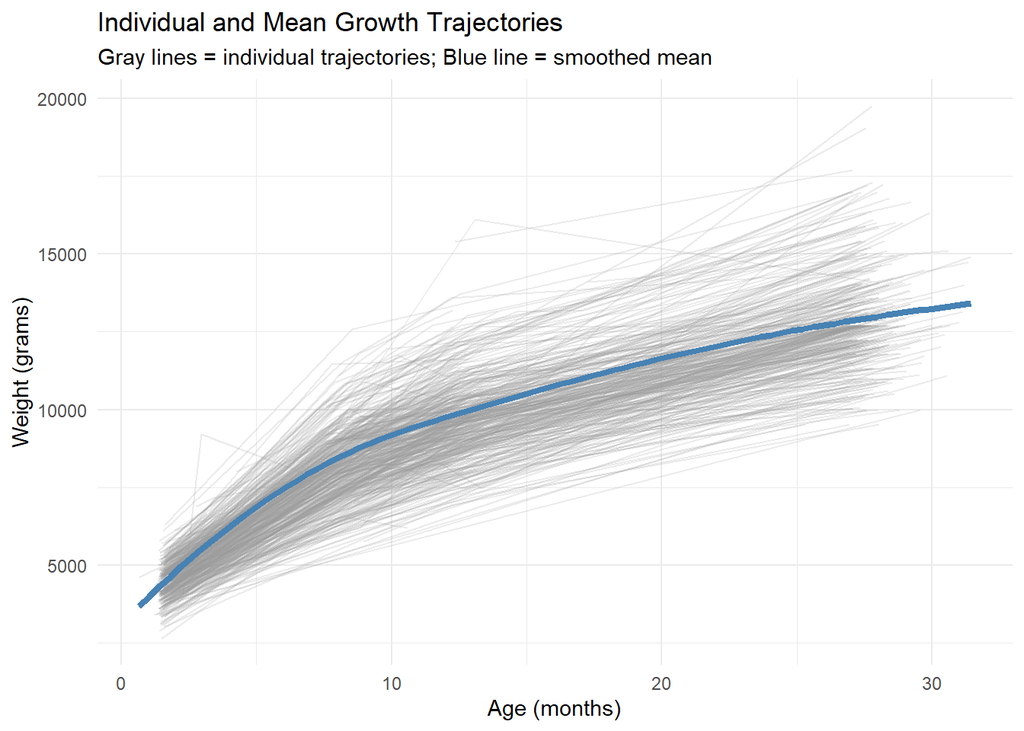

```r
# Compute the overall mean weight by age (binned for visualization)
mean_trajectory <- asian_data |>
mutate(age_bin = round(Age)) |>
group_by(age_bin) |>
summarise(mean_weight = mean(Weight, na.rm = TRUE), .groups = "drop")

# Create spaghetti plot
ggplot(asian_data, aes(x = Age, y = Weight)) +
geom_line(aes(group = ChildID), alpha = 0.2, color = "gray60") +
geom_smooth(method = "loess", se = FALSE, color = "steelblue", linewidth = 1.5) +
labs(
title = "Individual and Mean Growth Trajectories",
subtitle = "Gray lines = individual trajectories; Blue line = smoothed mean",
x = "Age (months)",
y = "Weight (grams)"
) +
theme_minimal()
```

**NoteObservations:**

• Clear upward trend: children gain weight as they age

• Growth appears to decelerate at older ages (suggesting a quadratic or higher-order term may be needed)

• Substantial variation in both baseline weight and growth rates between children

## Examining individual trajectories in details

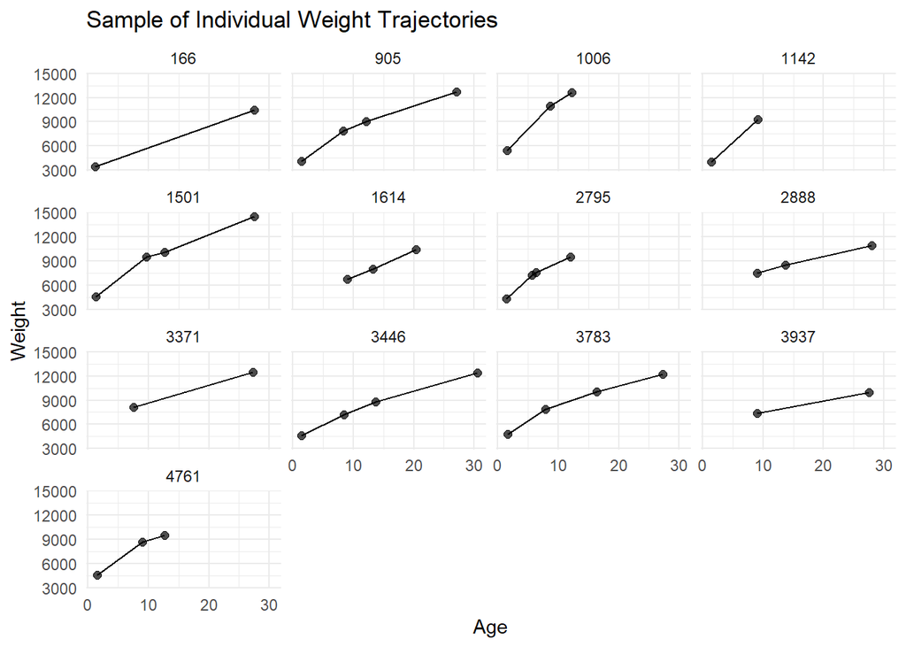

```r
set.seed(123)  # Set seed for reproducibility

# Sample 16 unique individuals
sampled_ids <- sample(1:5020, 80)

# Filter dataset for the sampled IDs and plot
asian_data |>
  filter(ChildID %in% sampled_ids) |>
  ggplot(aes(x = Age, y = Weight)) +
  geom_line() +                               # Add trajectories (lines)
  geom_point(size = 2, alpha = 0.7) +         # Add individual data points (dots)
  facet_wrap(~ ChildID) +                          # Create a subplot for each individual
  labs(
    title = "Sample of Individual Weight Trajectories",
    x = "Age",
    y = "Weight"
  ) +
  theme_minimal()
```

**NoteObservations:**

The individual trajectories show increasing trend over time. The heterogeneity in both baseline levels (the weights at birth were different) and rates of change motivates the use of random intercepts and random slopes in the models.

## Mean trajectories by gender

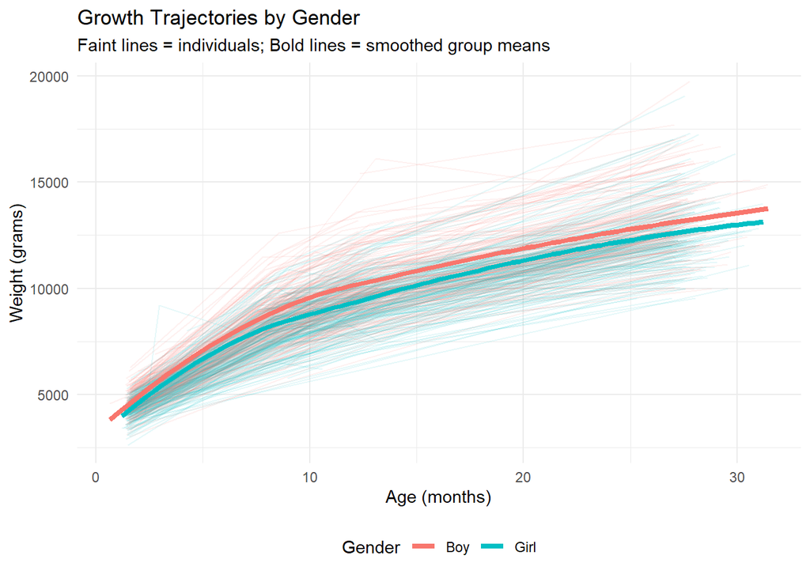

```r
# Compute mean trajectories by gender
mean_by_gender <- asian_data |>
  mutate(age_bin = round(Age)) |>
  group_by(age_bin, Gender) |>
  summarise(mean_weight = mean(Weight, na.rm = TRUE), .groups = "drop")
# Plot mean trajectories by gender
ggplot(asian_data, aes(x = Age, y = Weight, color = Gender)) +
  geom_line(aes(group = ChildID), alpha = 0.1) +
  geom_smooth(method = "loess", se = FALSE, linewidth = 1.5) +
  labs(
    title = "Growth Trajectories by Gender",
    subtitle = "Faint lines = individuals; Bold lines = smoothed group means",
    x = "Age (months)",
    y = "Weight (grams)",
    color = "Gender"
) +
  theme_minimal() +
  theme(legend.position = "bottom")
```

**NoteObservations:**

• Boys appear to be heavier than girls on average throughout the age range

• The trajectories appear roughly parallel, suggesting a main effect of gender but possibly no interaction with time

# 5. Fit a flexible model for time:

We start with a model that includes linear and quadratic terms for time, along with random intercept and random slope.

```r
# Fit the full time model with quadratic polynomial and random slope
# Using poly() with raw = TRUE gives interpretable coefficients
time_model_full <- lmer(Weight ~ poly(age_c, 2, raw = TRUE) + (age_c | ChildID),
data = asian_data,
control = lmerControl(optimizer = "bobyqa"))
summary(time_model_full)
```

```
Linear mixed model fit by REML. t-tests use Satterthwaite's method [
lmerModLmerTest]
Formula: Weight ~ poly(age_c, 2, raw = TRUE) + (age_c | ChildID)
   Data: asian_data
Control: lmerControl(optimizer = "bobyqa")

REML criterion at convergence: 26022.4

Scaled residuals:
    Min      1Q  Median      3Q     Max
-4.0532 -0.4660 -0.0464  0.4363  6.2139

Random effects:
 Groups   Name        Variance Std.Dev. Corr
 ChildID  (Intercept) 789436   888.50
          age_c         1812    42.57   0.93
 Residual             470199   685.71
Number of obs: 1572, groups:  ChildID, 568

Fixed effects:
                             Estimate Std. Error        df t value Pr(>|t|)
(Intercept)                 9857.0980    47.7597  821.3002  206.39   <2e-16 ***
poly(age_c, 2, raw = TRUE)1  386.0447     3.1596  712.4479  122.18   <2e-16 ***
poly(age_c, 2, raw = TRUE)2  -12.1205     0.2476  939.1277  -48.96   <2e-16 ***
---
Signif. codes:  0 '***' 0.001 '**' 0.01 '*' 0.05 '.' 0.1 ' ' 1

Correlation of Fixed Effects:
               (Intr) p(_,2,r=TRUE)1
p(_,2,r=TRUE)1  0.670
p(_,2,r=TRUE)2 -0.462 -0.440
```

## 5.1 Test the random slope:

Use a likelihood ratio test (refit = FALSE) to determine whether the random slope for time is necessary.

```r
# Fit model with random intercept only
time_model_ri <- lmer(Weight ~ poly(age_c, 2, raw = TRUE) + (1 | ChildID),
                      data = asian_data,
                      control = lmerControl(optimizer = "bobyqa"))
# Compare models using LRT (refit = FALSE for random effects)
anova(time_model_ri, time_model_full, refit = FALSE)
```

```
Data: asian_data
Models:
time_model_ri: Weight ~ poly(age_c, 2, raw = TRUE) + (1 | ChildID)
time_model_full: Weight ~ poly(age_c, 2, raw = TRUE) + (age_c | ChildID)
                npar   AIC   BIC logLik -2*log(L)  Chisq Df Pr(>Chisq)
time_model_ri      5 26323 26350 -13157     26313
time_model_full    7 26036 26074 -13011     26022 291.02  2  < 2.2e-16 ***
---
Signif. codes:  0 '***' 0.001 '**' 0.01 '*' 0.05 '.' 0.1 ' ' 1
```

**NoteConclusion:**

The random slope is highly significant (p < 0.001), indicating that children differ in their growth rates. We retain the random slope structure.

## 5.2 Calculate the ICC:

Based on the random intercept model, calculate and interpret the ICC.

```r
# Extract variance components from the random intercept model
vc <- as.data.frame(VarCorr(time_model_ri))
var_intercept <- vc$vcov[1]
var_residual <- vc$vcov[2]
# Calculate ICC
icc <- var_intercept / (var_intercept + var_residual)
cat("Variance between children:", round(var_intercept, 0), "\n")
```

```
Variance between children: 763219
```

```r
cat("Variance within children:", round(var_residual, 0), "\n")
```

```
Variance within children: 670319
```

```r
cat("ICC:", round(icc, 3), "\n")
```

```
ICC: 0.532
```

**NoteInterpretation:**

The ICC indicates that approximately 53% of the variance in weight (after accounting for age trends) is due to stable differences between children.

## 5.3 Test the fixed effects for time:

We test the polynomial terms starting from the highest order, keeping the random slope structure throughout.

```r
# Test quadratic term by comparing to linear-only model
time_model_linear <- lmer(Weight ~ poly(age_c, 1, raw = TRUE) + (age_c | ChildID),
                          data = asian_data,
                          control = lmerControl(optimizer = "bobyqa"))
anova(time_model_linear, time_model_full, refit = TRUE)
```

```
Data: asian_data
Models:
time_model_linear: Weight ~ poly(age_c, 1, raw = TRUE) + (age_c | ChildID)
time_model_full: Weight ~ poly(age_c, 2, raw = TRUE) + (age_c | ChildID)
                  npar   AIC   BIC logLik -2*log(L)  Chisq Df Pr(>Chisq)
time_model_linear    6 27330 27362 -13659     27318
time_model_full      7 26048 26086 -13017     26034 1283.4  1  < 2.2e-16 ***
---
Signif. codes:  0 '***' 0.001 '**' 0.01 '*' 0.05 '.' 0.1 ' ' 1
```

**NoteConclusion:**

The quadratic term is highly significant (p < 0.001). The final time model includes linear and quadratic terms.

## 5.4 Check residual diagnostics:

Create a residuals vs. fitted plot to verify that the time trend is adequately captured.

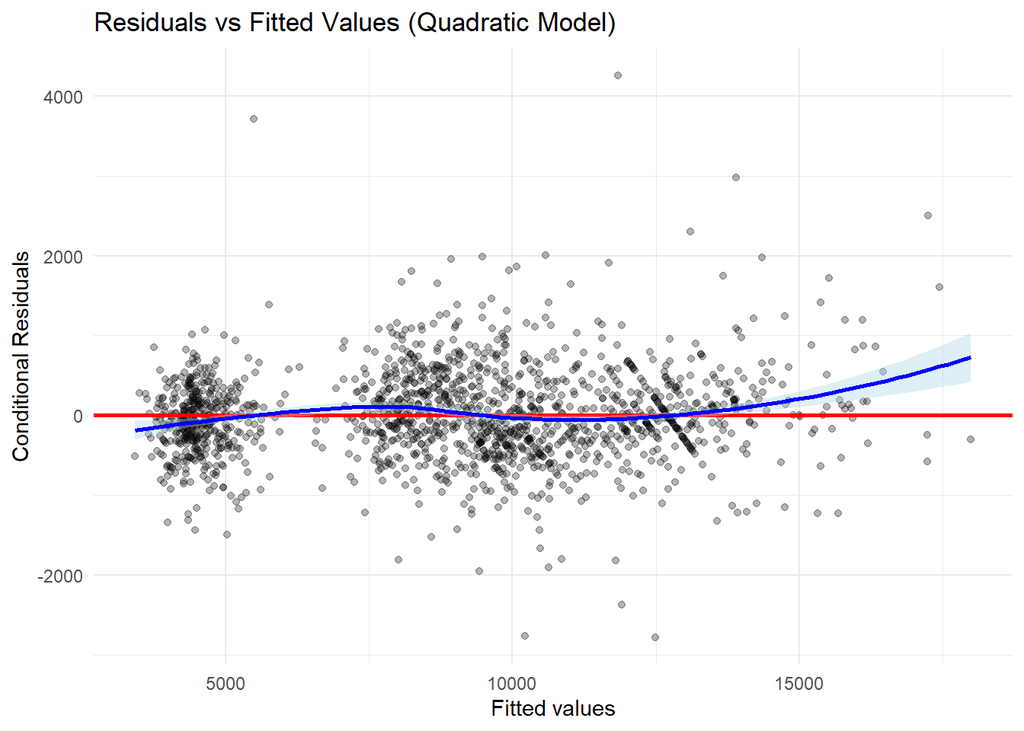

```r
# Create diagnostic plot for quadratic model
diag_data <- data.frame(
  fitted = fitted(time_model_full),
  residuals = resid(time_model_full)
)
ggplot(diag_data, aes(x = fitted, y = residuals)) +
  geom_point(alpha = 0.3) +
  geom_hline(yintercept = 0, color = "red", linewidth = 1) +
  geom_smooth(method = "loess", se = TRUE, color = "blue", fill = "lightblue") +
  labs(
    title = "Residuals vs Fitted Values (Quadratic Model)",
    x = "Fitted values",
    y = "Conditional Residuals"
    ) +
  theme_minimal()
```

# Comparing with linear-only model

To illustrate the consequences of under-specifying the time structure, we examine the residual diagnostics from the linear-only model.

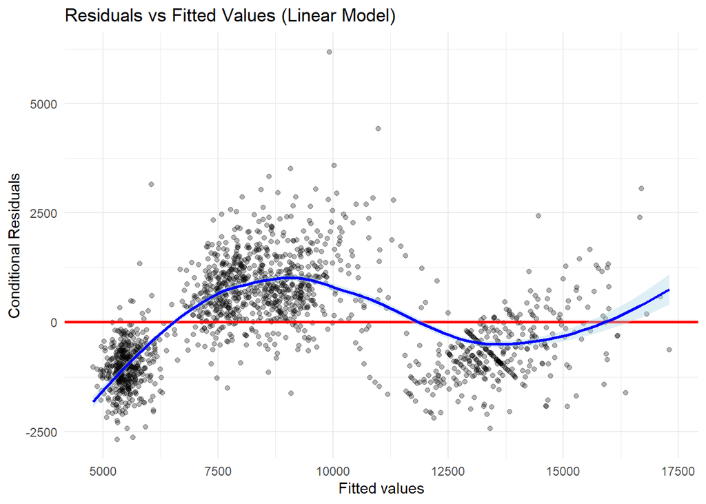

```r
# Diagnostic plot for linear model
diag_data_linear <- data.frame(
  fitted = fitted(time_model_linear),
  residuals = resid(time_model_linear)
)
ggplot(diag_data_linear, aes(x = fitted, y = residuals)) +
  geom_point(alpha = 0.3) +
  geom_hline(yintercept = 0, color = "red", linewidth = 1) +
  geom_smooth(method = "loess", se = TRUE, color = "blue", fill = "lightblue") +
  labs(
    title = "Residuals vs Fitted Values (Linear Model)",
    x = "Fitted values",
    y = "Conditional Residuals"
    ) +
  theme_minimal()
```

**NoteObservations:**

• Linear model: The loess curve shows a clear curved pattern, substantially deviating from zero. The model systematically over-predicts at low and high fitted values and under-predicts in the middle range. This is a classic sign that the linear time trend is inadequate and a quadratic term is needed.

This diagnostic plot demonstrates the importance of checking residuals when modeling longitudinal data.

# 6. Add the gender covariate

We add gender and its interactions with the time terms.

```r
# Fit model with gender main effect and interactions with time
full_model <- lmer(
  Weight ~ poly(age_c, 2, raw = TRUE) * Gender + (age_c | ChildID),
  data = asian_data,
  control = lmerControl(optimizer = "bobyqa")
)
summary(full_model)
```

```
Linear mixed model fit by REML. t-tests use Satterthwaite's method [
lmerModLmerTest]
Formula: Weight ~ poly(age_c, 2, raw = TRUE) * Gender + (age_c | ChildID)
   Data: asian_data
Control: lmerControl(optimizer = "bobyqa")

REML criterion at convergence: 25939.5

Scaled residuals:
    Min      1Q  Median      3Q     Max
-4.4313 -0.4787 -0.0369  0.4268  6.0512

Random effects:
 Groups   Name        Variance Std.Dev. Corr
 ChildID  (Intercept) 742475   861.67
          age_c         1843    42.93   0.96
 Residual             459647   677.97
Number of obs: 1572, groups:  ChildID, 568

Fixed effects:
                                     Estimate Std. Error        df t value
(Intercept)                         9853.6095    46.6407  817.7990 211.266
poly(age_c, 2, raw = TRUE)1          385.7775     3.1387  704.8026 122.908
poly(age_c, 2, raw = TRUE)2          -12.1079     0.2439  942.3944 -49.635
Gender1                              345.2809    46.6407  817.7990   7.403
poly(age_c, 2, raw = TRUE)1:Gender1    7.3827     3.1387  704.8026   2.352
poly(age_c, 2, raw = TRUE)2:Gender1   -1.1698     0.2439  942.3944  -4.795
                                    Pr(>|t|)
(Intercept)                          < 2e-16 ***
poly(age_c, 2, raw = TRUE)1          < 2e-16 ***
poly(age_c, 2, raw = TRUE)2          < 2e-16 ***
Gender1                             3.31e-13 ***
poly(age_c, 2, raw = TRUE)1:Gender1   0.0189 *
poly(age_c, 2, raw = TRUE)2:Gender1 1.89e-06 ***
---
Signif. codes:  0 '***' 0.001 '**' 0.01 '*' 0.05 '.' 0.1 ' ' 1

Correlation of Fixed Effects:
                (Intr) pl(_,2,r=TRUE)1 pl(_,2,r=TRUE)2 Gendr1 p(_,2,r=TRUE)1:
pl(_,2,r=TRUE)1  0.690
pl(_,2,r=TRUE)2 -0.467 -0.434
Gender1         -0.014 -0.015           0.019
p(_,2,r=TRUE)1: -0.015 -0.025           0.026           0.690
p(_,2,r=TRUE)2:  0.019  0.026          -0.019          -0.467 -0.434
```

We use the step() function to perform backward elimination of non-significant fixed effects.

```r
# Use step() to simplify fixed effects
step_result <- step(full_model, reduce.fixed = TRUE, reduce.random = FALSE)
print(step_result)
```

```
Backward reduced random-effect table:

                           Eliminated npar logLik   AIC    LRT Df Pr(>Chisq)
<none>                                  10 -12970 25960
age_c in (age_c | ChildID)          0    8 -13127 26269 313.89  2  < 2.2e-16

<none>
age_c in (age_c | ChildID) ***
---
Signif. codes:  0 '***' 0.001 '**' 0.01 '*' 0.05 '.' 0.1 ' ' 1

Backward reduced fixed-effect table:
Degrees of freedom method: Satterthwaite

                                  Eliminated   Sum Sq Mean Sq NumDF  DenDF
poly(age_c, 2, raw = TRUE):Gender          0 10611023 5305511     2 873.64
                                  F value    Pr(>F)
poly(age_c, 2, raw = TRUE):Gender  11.543 1.128e-05 ***
---
Signif. codes:  0 '***' 0.001 '**' 0.01 '*' 0.05 '.' 0.1 ' ' 1

Model found:
Weight ~ poly(age_c, 2, raw = TRUE) * Gender + (age_c | ChildID)
```

```r
# Extract the final model
final_model <- get_model(step_result)
```

# Final model summary

```r
# Display the final model summary
summary(final_model)
```

```
Linear mixed model fit by REML. t-tests use Satterthwaite's method [
lmerModLmerTest]
Formula: Weight ~ poly(age_c, 2, raw = TRUE) * Gender + (age_c | ChildID)
   Data: asian_data
Control: lmerControl(optimizer = "bobyqa")

REML criterion at convergence: 25939.5

Scaled residuals:
    Min      1Q  Median      3Q     Max
-4.4313 -0.4787 -0.0369  0.4268  6.0512

Random effects:
 Groups   Name        Variance Std.Dev. Corr
 ChildID  (Intercept) 742475   861.67
          age_c         1843    42.93   0.96
 Residual             459647   677.97
Number of obs: 1572, groups:  ChildID, 568

Fixed effects:
                                     Estimate Std. Error        df t value
(Intercept)                         9853.6095    46.6407  817.7990 211.266
poly(age_c, 2, raw = TRUE)1          385.7775     3.1387  704.8026 122.908
poly(age_c, 2, raw = TRUE)2          -12.1079     0.2439  942.3944 -49.635
Gender1                              345.2809    46.6407  817.7990   7.403
poly(age_c, 2, raw = TRUE)1:Gender1    7.3827     3.1387  704.8026   2.352
poly(age_c, 2, raw = TRUE)2:Gender1   -1.1698     0.2439  942.3944  -4.795
                                    Pr(>|t|)
(Intercept)                          < 2e-16 ***
poly(age_c, 2, raw = TRUE)1          < 2e-16 ***
poly(age_c, 2, raw = TRUE)2          < 2e-16 ***
Gender1                             3.31e-13 ***
poly(age_c, 2, raw = TRUE)1:Gender1   0.0189 *
poly(age_c, 2, raw = TRUE)2:Gender1 1.89e-06 ***
---
Signif. codes:  0 '***' 0.001 '**' 0.01 '*' 0.05 '.' 0.1 ' ' 1

Correlation of Fixed Effects:
                (Intr) pl(_,2,r=TRUE)1 pl(_,2,r=TRUE)2 Gendr1 p(_,2,r=TRUE)1:
pl(_,2,r=TRUE)1  0.690
pl(_,2,r=TRUE)2 -0.467 -0.434
Gender1         -0.014 -0.015           0.019
p(_,2,r=TRUE)1: -0.015 -0.025           0.026           0.690
p(_,2,r=TRUE)2:  0.019  0.026          -0.019          -0.467 -0.434
```